# FCR_Process_BD

Brenda D’Achuna, Alex Hounshell, Adrienne Breef-Pilz

2025-01-24

This script: Following initial data corrections in Eddy Pro (using standard processing) and light data cleaning via EddyPro_CleanUp.R

Original code from Brenda D’Achuna, 21 May 2021 Modified by Alex Hounshell on 21 May 2021 Updated by Bibek Kandel on 24 Jan 2025

1. Compile data
2. Read in Met files from Environmental Data Initiative
3. Adjust values and do additional QAQC
4. Use de spike function to remove values
5. Add Met values as needed
6. Gaps fill. Beware this takes HOURS!!!!!
7. Save files
8. Plots for checks

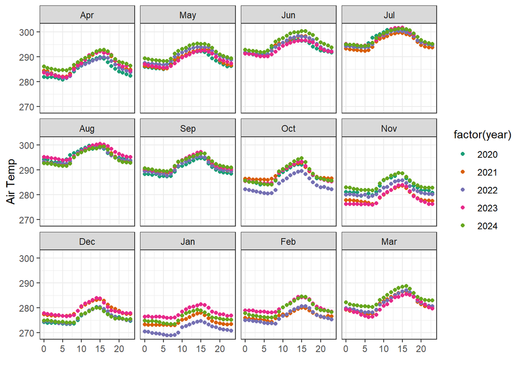

```
## # A tibble: 57 × 4
## # Groups:   year(datetime) [5]
##    `year(datetime)` `month(datetime)` co2_available ch4_available
##               <dbl>             <dbl>         <dbl>         <dbl>
##  1             2020                 4          78.6          56.7
##  2             2020                 5          83.5          57.8
##  3             2020                 6          82.2          59.0
##  4             2020                 7          77.8          70.7
##  5             2020                 8          21.8          16.3
##  6             2020                 9          79.8          73.3
##  7             2020                10          85.1          60.3
##  8             2020                11          87.8          78.1
##  9             2020                12          95.3          55.8
## 10             2021                 1          94.1          72.8
## # ℹ 47 more rows
```

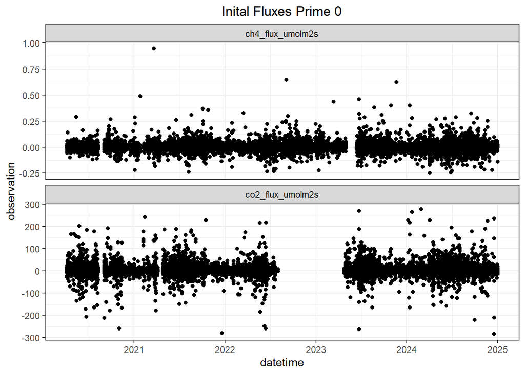

Count how many initial NAs are in CO2 and CH4 data. Without any data processing! 72.2% data for Co2;  
74.8% data for Ch4

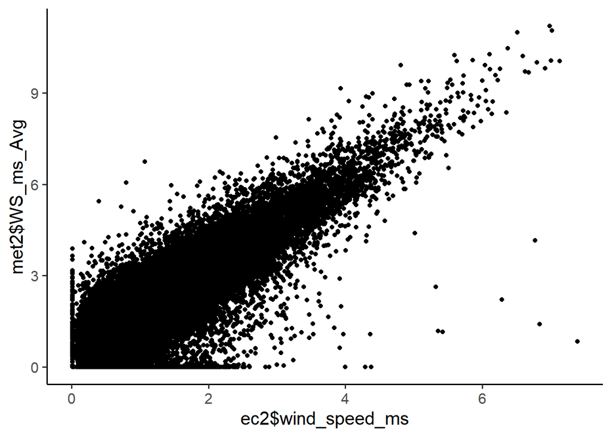

```r
# Compare wind speeds from EC and Met

ggplot()+
  geom_point(aes(x=ec2$wind_speed_ms, y=met2$WS_ms_Avg))+
  theme_classic(base_size = 15)
```

```r
# Calculate percent of missing wind data
# 10.4% missing
miss_ws<-ec2 %>% select(datetime, wind_speed_ms) %>%
  summarise(wnd_na = sum(is.na(wind_speed_ms))/n()*100)
```

We are missing 10.4 % of the windspeed observations

```r
# Use linear model to convert from Met to EC for missing time point
linearMod <- lm(ec2$wind_speed_ms ~ met2$WS_ms_Avg)
summary(linearMod)
```

```
##
## Call:
## lm(formula = ec2$wind_speed_ms ~ met2$WS_ms_Avg)
##
## Residuals:
##     Min      1Q  Median      3Q     Max
## -2.7359 -0.2241 -0.0048  0.1950  6.7815
##
## Coefficients:
##                Estimate Std. Error t value Pr(>|t|)
## (Intercept)    0.154306   0.002725   56.63   <2e-16 ***
## met2$WS_ms_Avg 0.541570   0.001213  446.46   <2e-16 ***
## ---
## Signif. codes:  0 '***' 0.001 '**' 0.01 '*' 0.05 '.' 0.1 ' ' 1
##
## Residual standard error: 0.3909 on 74445 degrees of freedom
##   (8642 observations deleted due to missingness)
## Multiple R-squared:  0.7281, Adjusted R-squared:  0.7281
## F-statistic: 1.993e+05 on 1 and 74445 DF,  p-value: < 2.2e-16
```

```r
cor(ec2[[49]],met2[[11]],use = "complete.obs",method=c("pearson"))
```

```
## [1] 0.8532747
```

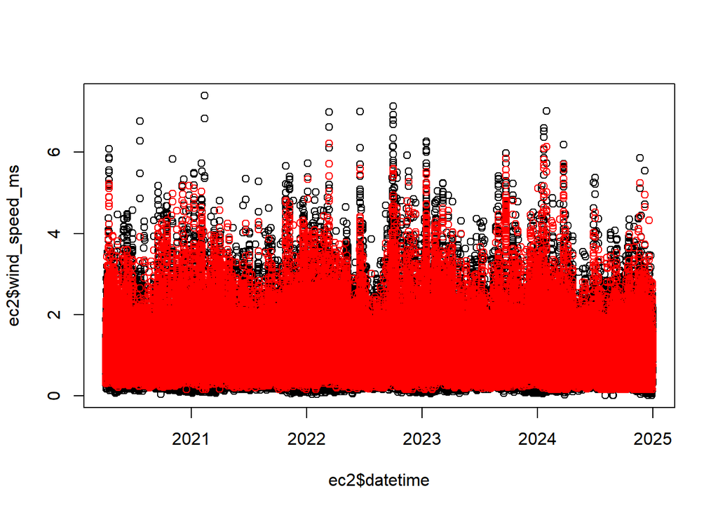

```r
# UPDATE EVERY YEAR WITH NEW RELATIONSHIP
# For data period: EC = Met*0.541570+0.154306

# Check conversion - UPDATE EVERY YEAR WITH NEW RELATIONSHIP
plot(ec2$datetime, ec2$wind_speed_ms)
points(ec2$datetime, met2$WS_ms_Avg*(summary(linearMod)$coefficients[2, 1])+(summary(linearMod)$coefficients[1, 1]), col = 'red')
```

The new relationship between the wind speed on the Metstation and the EddyFlux is

EC= Met* 0.5415703 + 0.1543065

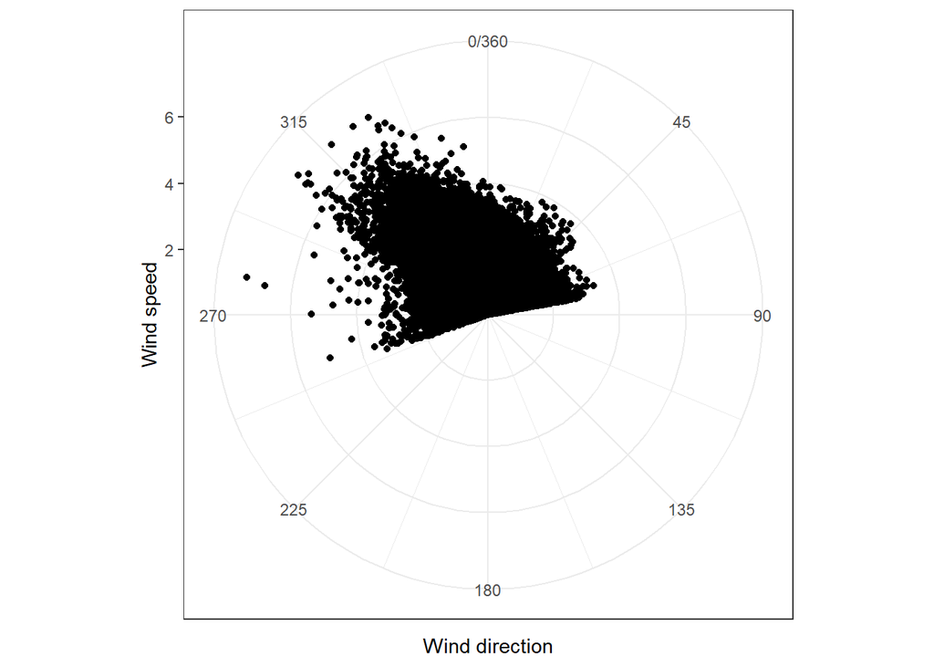

```r
###########################################
# Use converted wind speed from the Met data to fill in time points with missing
# data (EC)
# UPDATE EVERY YEAR WITH NEW RELATIONSHIP
ec2$wind_speed_ms <- ifelse(is.na(ec2$wind_speed_ms),
                         met2$WS_ms_Avg*(summary(linearMod)$coefficients[2, 1])+
                           (summary(linearMod)$coefficients[1, 1]), ec2$wind_speed_ms)

ec2$wind_dir <- ifelse(is.na(ec2$wind_dir),
                       met2$WindDir, ec2$wind_dir)

# Visualize wind directions that are IN FRONT of the catwalk
ec2 %>% filter(wind_dir >= 250 | wind_dir <= 80) %>%
  ggplot(aes(wind_dir, wind_speed_ms)) +
  geom_point() +
  scale_x_continuous(limits = c(0, 360),
                     breaks = seq(0, 360, 45)) +
  coord_polar() + theme_bw() + xlab('Wind direction') + ylab('Wind speed')
```

```r
# Filter out wind directions that are BEHIND the catwalk
# I.e., only keep data that is IN FRONT of the catwalk for both EC and Met data
ec_filt <- ec2 %>% dplyr::filter(wind_dir < 80 | wind_dir > 250)
ec_filt <- left_join(ts2, ec_filt)
met3 <- met2 %>% dplyr::filter(WindDir < 80 | WindDir > 250)
met4 <- left_join(ts2, met3)
################################################################
# count NA after filtering for wind direction BEHIND catwalk
ec_filt %>% select(datetime, co2_flux_umolm2s, ch4_flux_umolm2s) %>%
  summarise(co2_available = 100- sum(is.na(co2_flux_umolm2s))/n()*100,
            ch4_available = 100-sum(is.na(ch4_flux_umolm2s))/n()*100)
```

```
##   co2_available ch4_available
## 1      50.34722      53.35363
```

```r
# Now have 50.34% CO2 data and 53.35% CH4 data

# Count number of timepoints that have data
ec_filt %>% select(datetime, co2_flux_umolm2s, ch4_flux_umolm2s) %>%
  summarise(co2_available = n() - sum(is.na(co2_flux_umolm2s)),
            ch4_available = n() -sum(is.na(ch4_flux_umolm2s)))
```

```
##   co2_available ch4_available
## 1         41833         44331
```

```r
################################################################
```

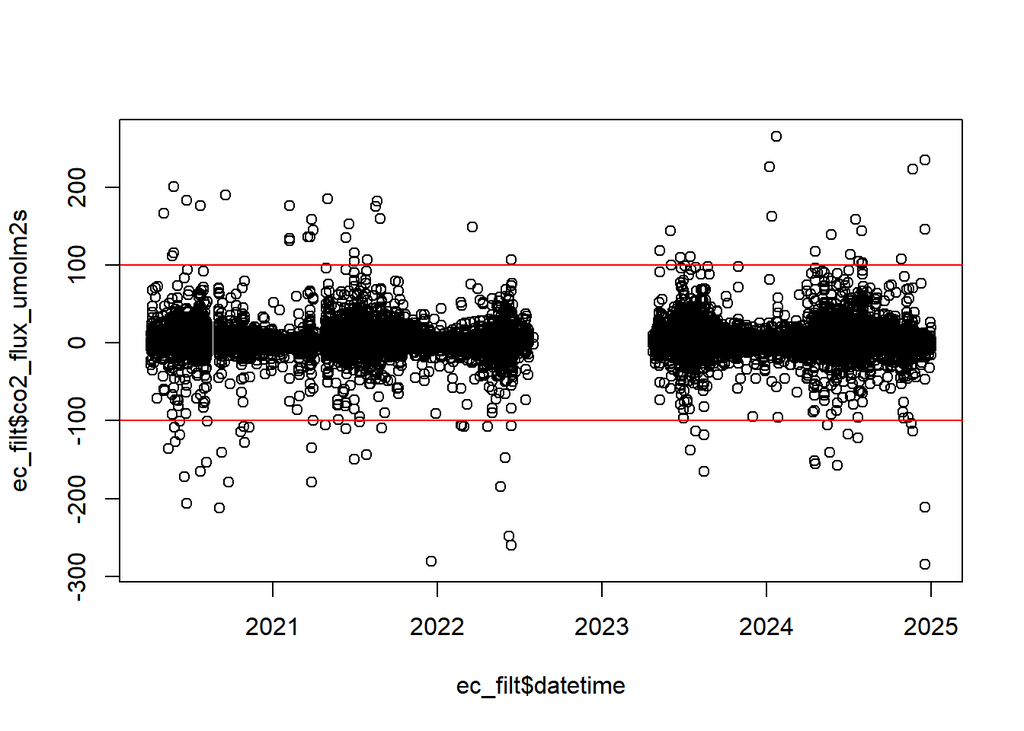

```
## integer(0)
```

```r
# Remove large CO2 values
# Visualize data that is above/below abs(100)
plot(ec_filt$datetime, ec_filt$co2_flux_umolm2s)+
abline(h=100, col="red") +
abline(h=-100, col="red")
```

```r
# Remove values that are greater than abs(100)
# NOTE: Updated from Brenda's code to use abs(100); instead of -70 to 100 filtering
# Waldo et al. 2021 used: values greater than abs(15000)
ec_filt$co2_flux_umolm2s <- ifelse(ec_filt$co2_flux_umolm2s > 100 | ec_filt$co2_flux_umolm2s < -100, NA, ec_filt$co2_flux_umolm2s)

# Remove CO2 data if QC >= 2 (aka: data that has been flagged by Eddy Pro)
ec_filt$co2_flux_umolm2s <- ifelse(ec_filt$qc_co2_flux >= 2, NA, ec_filt$co2_flux_umolm2s)

# Additionally remove CO2 data when H and LE > 2 (following CH4 filtering)
ec_filt$co2_flux_umolm2s <- ifelse(ec_filt$qc_co2_flux==1 & ec_filt$qc_LE>=2, NA, ec_filt$co2_flux_umolm2s)
ec_filt$co2_flux_umolm2s <- ifelse(ec_filt$qc_co2_flux==1 & ec_filt$qc_H>=2, NA, ec_filt$co2_flux_umolm2s)
```

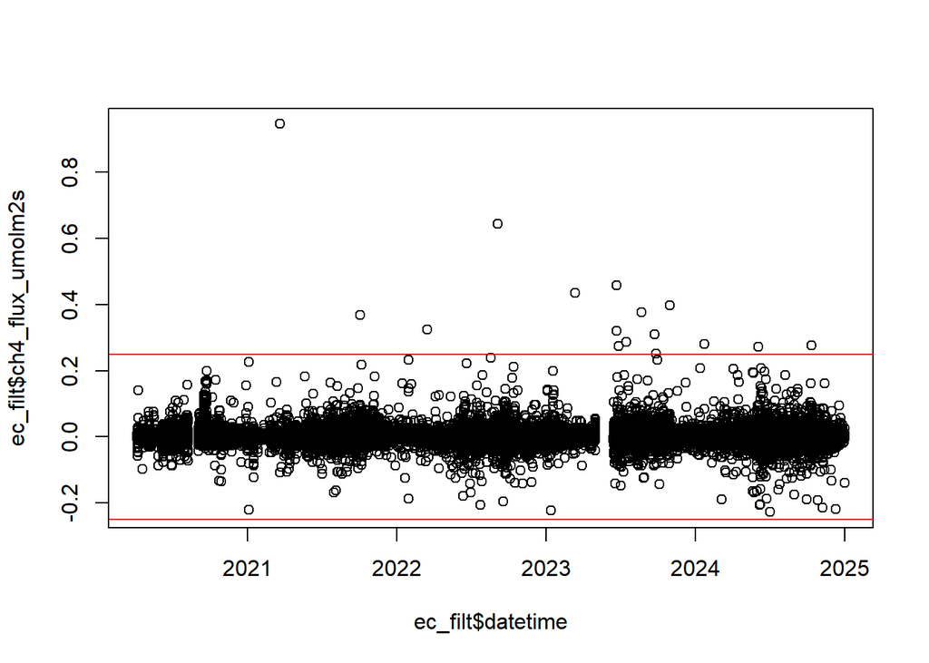

```
## integer(0)
```

```r
# Remove large CH4 values
# Visualize data that is above/below abs(0.25)
plot(ec_filt$datetime, ec_filt$ch4_flux_umolm2s)+
abline(h=0.25, col='red')+
abline(h=-0.25, col='red')
```

```r
# Remove values that are greater than abs(0.25)
# NOTE: Updated from Brenda's code to use abs(0.25)
# Waldo et al. 2021 used: values greater than abs(500)
ec_filt$ch4_flux_umolm2s <- ifelse(ec_filt$ch4_flux_umolm2s >= 0.25 | ec_filt$ch4_flux_umolm2s <= -0.25, NA, ec_filt$ch4_flux_umolm2s)

# Remove ch4 values when signal strength < 20
ec_filt$ch4_flux_umolm2s <- ifelse(ec_filt$rssi_77_mean < 20, NA, ec_filt$ch4_flux_umolm2s)

# Remove CH4 data if QC >= 2
ec_filt$ch4_flux_umolm2s <- ifelse(ec_filt$qc_ch4_flux >=2, NA, ec_filt$ch4_flux_umolm2s)

# Additionally, remove CH4 when other parameters are QA/QC'd
# Following Waldo et al. 2021: Remove additional ch4 flux data
# (aka: anytime ch4_qc flag = 1 & another qc_flag =2, remove)
ec_filt$ch4_flux_umolm2s <- ifelse(ec_filt$qc_ch4_flux==1 & ec_filt$qc_co2_flux>=2, NA, ec_filt$ch4_flux_umolm2s)
ec_filt$ch4_flux_umolm2s <- ifelse(ec_filt$qc_ch4_flux==1 & ec_filt$qc_LE>=2, NA, ec_filt$ch4_flux_umolm2s)
ec_filt$ch4_flux_umolm2s <- ifelse(ec_filt$qc_ch4_flux==1 & ec_filt$qc_H>=2, NA, ec_filt$ch4_flux_umolm2s)
```

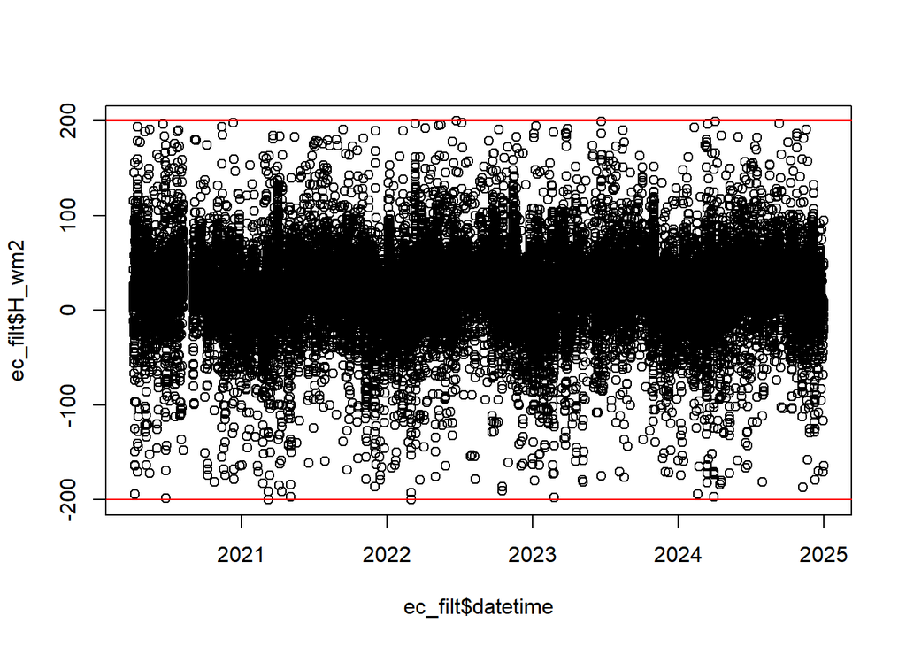

```
## integer(0)
```

```r
# Removing qc >= 2 for H and LE
ec_filt$H_wm2 <- ifelse(ec_filt$qc_H >= 2, NA, ec_filt$H_wm2)
ec_filt$LE_wm2 <- ifelse(ec_filt$qc_LE >= 2, NA, ec_filt$LE_wm2)

# Remove high H values: greater than abs(200)
# NOTE: Updated to have same upper and lower magnitude bound
# Waldo et al. 2021 used abs of 200 for H
plot(ec_filt$datetime, ec_filt$H_wm2)+
abline(h=200, col='red')+
abline(h=-200, col='red')
```

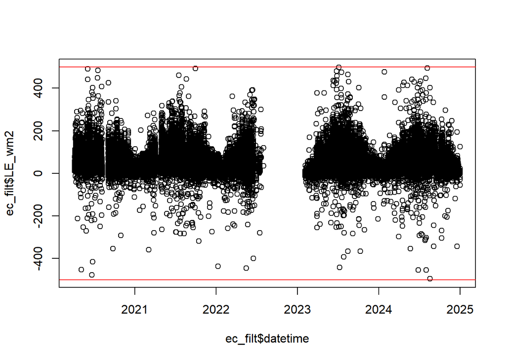

```
## integer(0)
```

```r
ec_filt$H_wm2 <- ifelse(ec_filt$H_wm2 >= 200 | ec_filt$H_wm2 <= -200, NA, ec_filt$H_wm2)

# Remove high LE values: greater than abs(500)
# NOTE: Updated to have same upper and lower magnitude bounds
# Waldo et al. 2021 used abs of 1000 for LE
plot(ec_filt$datetime,ec_filt$LE_wm2)+
abline(h=500, col='red')+
abline(h=-500, col='red')
```

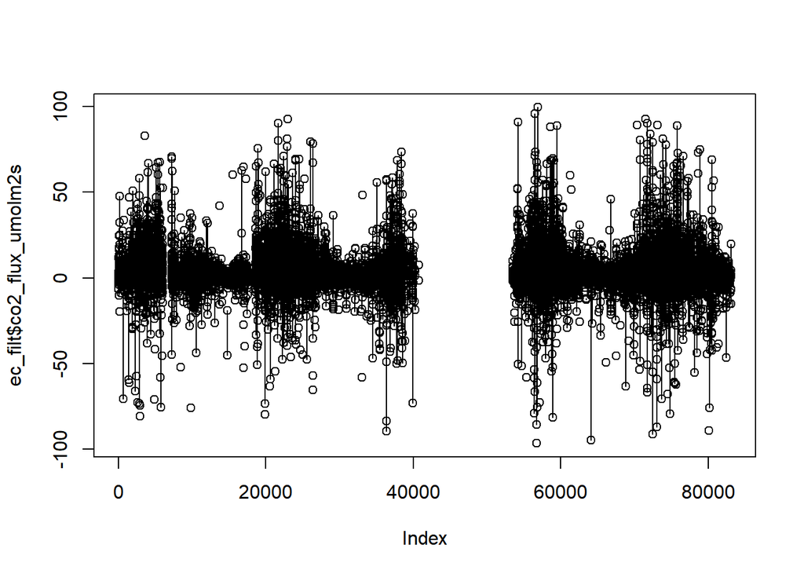

```r
ec_filt$LE_wm2 <- ifelse(ec_filt$LE_wm2 >= 500 | ec_filt$LE_wm2 <= -500, NA, ec_filt$LE_wm2)

# Plotting co2 and ch4 to see if we can filter implausible values
plot(ec_filt$co2_flux_umolm2s, type = 'o')
```

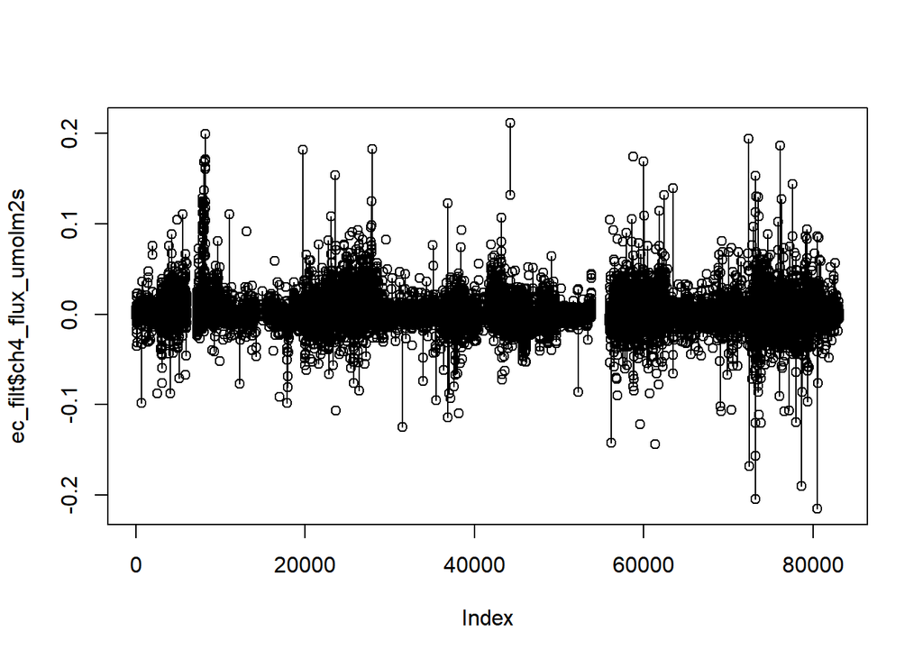

```r
plot(ec_filt$ch4_flux_umolm2s, type = 'o')
```

```r
################################################################
# count NA after filtering for bad fluxes
ec_filt %>% select(datetime, co2_flux_umolm2s, ch4_flux_umolm2s) %>%
  summarise(co2_available = 100- sum(is.na(co2_flux_umolm2s))/n()*100,
            ch4_available = 100-sum(is.na(ch4_flux_umolm2s))/n()*100)
```

```
##   co2_available ch4_available
## 1      32.61924      30.30606
```

```r
# Now have 32.62% CO2 data and 30.31% CH4 data

# Count number of timepoints that have data
ec_filt %>% select(datetime, co2_flux_umolm2s, ch4_flux_umolm2s) %>%
  summarise(co2_available = n() - sum(is.na(co2_flux_umolm2s)),
            ch4_available = n() -sum(is.na(ch4_flux_umolm2s)))
```

```
##   co2_available ch4_available
## 1         27103         25181
```

```r
################################################################

# Remove CH4 when it rains
ec_filt$precip <- met2$Rain_sum
ec_filt$ch4_flux_umolm2s <- ifelse(ec_filt$precip > 0, NA, ec_filt$ch4_flux_umolm2s)

# Remove CH4 data when thermocouple was not working (apr 05 - apr 25) # ABP find for 2023
ec_filt$ch4_flux_umolm2s <- ifelse(ec_filt$datetime >= '2021-04-05' & ec_filt$datetime <= '2021-04-25',
                           NA, ec_filt$ch4_flux_umolm2s)

# Merge with timeseries
eddy_fcr <- left_join(ts2, ec_filt, by = 'datetime')
```

```r
#######################################################################
# counting data again after filtering by:
# wind direction, qc, rain, unreasonable values, signal strength
eddy_fcr %>% select(datetime, co2_flux_umolm2s, ch4_flux_umolm2s) %>%
  summarise(co2_available = 100-sum(is.na(co2_flux_umolm2s))/n()*100,
            ch4_available = 100-sum(is.na(ch4_flux_umolm2s))/n()*100)
```

```
##   co2_available ch4_available
## 1      32.61924      29.86797
```

```r
# 32.62% CO2 data; 29.86% CH4 data

# Number of timepoints available
eddy_fcr %>% select(datetime, co2_flux_umolm2s, ch4_flux_umolm2s) %>%
  summarise(co2_available = n() - sum(is.na(co2_flux_umolm2s)),
            ch4_available = n() -sum(is.na(ch4_flux_umolm2s)))
```

```
##   co2_available ch4_available
## 1         27103         24817
```

```r
# Data availability by month
eddy_fcr %>% group_by(year(datetime), month(datetime)) %>% select(datetime, co2_flux_umolm2s, ch4_flux_umolm2s) %>%
  summarise(co2_available = 100-sum(is.na(co2_flux_umolm2s))/n()*100,
            ch4_available = 100-sum(is.na(ch4_flux_umolm2s))/n()*100)
```

```
## # A tibble: 57 × 4
## # Groups:   year(datetime) [5]
##    `year(datetime)` `month(datetime)` co2_available ch4_available
##               <dbl>             <dbl>         <dbl>         <dbl>
##  1             2020                 4         36.7          25.2
##  2             2020                 5         34.8          26.5
##  3             2020                 6         38.5          27.3
##  4             2020                 7         41.4          31.0
##  5             2020                 8          7.26          4.91
##  6             2020                 9         38.3          35.3
##  7             2020                10         40.5          27.4
##  8             2020                11         40.5          37.8
##  9             2020                12         45.4          25.5
## 10             2021                 1         46.6          35.9
## # ℹ 47 more rows
```

```r
########################################################################
# Despike data using despike.R function

# Despike NEE (CO2 flux)


# Calculate low, medium, and high data flags
flag <- spike_flag(eddy_fcr$co2_flux_umolm2s,z = 7)
```

```
## No. of outliers in left tail: 2
```

```
## No. of outliers in right tail: 7
```

```
## No. of outliers in left tail: 9
```

```
## No. of outliers in right tail: 15
```

```
## No. of outliers in left tail: 2
```

```
## No. of outliers in right tail: 2
```

```
## No. of outliers in left tail: 1
```

```
## No. of outliers in right tail: 0
```

```
## No outliers found
```

```
## No. of outliers in left tail: 2
```

```
## No. of outliers in right tail: 9
```

```
## No. of outliers in left tail: 2
```

```
## No. of outliers in right tail: 5
```

```
## No. of outliers in left tail: 2
```

```
## No. of outliers in right tail: 0
```

```
## No. of outliers in left tail: 3
```

```
## No. of outliers in right tail: 4
```

```
## No. of outliers in left tail: 6
```

```
## No. of outliers in right tail: 4
```

```
## No. of outliers in left tail: 3
```

```
## No. of outliers in right tail: 1
```

```
## No. of outliers in left tail: 3
```

```
## No. of outliers in right tail: 3
```

```
## No. of outliers in left tail: 3
```

```
## No. of outliers in right tail: 10
```

```
## No. of outliers in left tail: 5
```

```
## No. of outliers in right tail: 13
```

```
## No. of outliers in left tail: 3
```

```
## No. of outliers in right tail: 1
```

```
## No. of outliers in left tail: 0
```

```
## No. of outliers in right tail: 6
```

```
## No. of outliers in left tail: 0
```

```
## No. of outliers in right tail: 3
```

```
## No. of outliers in left tail: 3
```

```
## No. of outliers in right tail: 6
```

```
## No. of outliers in left tail: 3
```

```
## No. of outliers in right tail: 7
```

```
## No. of outliers in left tail: 0
```

```
## No. of outliers in right tail: 6
```

```
## No. of outliers in left tail: 4
```

```
## No. of outliers in right tail: 1
```

```
## No. of outliers in left tail: 2
```

```
## No. of outliers in right tail: 0
```

```
## No. of outliers in left tail: 5
```

```
## No. of outliers in right tail: 4
```

```
## No. of outliers in left tail: 5
```

```
## No. of outliers in right tail: 2
```

```
## No. of outliers in left tail: 6
```

```
## No. of outliers in right tail: 3
```

```
## No. of outliers in left tail: 2
```

```
## No. of outliers in right tail: 4
```

```
## No. of outliers in left tail: 0
```

```
## No. of outliers in right tail: 1
```

```
## No outliers found
## No outliers found
```

```
## No. of outliers in left tail: 1
```

```
## No. of outliers in right tail: 12
```

```
## No. of outliers in left tail: 1
```

```
## No. of outliers in right tail: 0
```

```
## No. of outliers in left tail: 1
```

```
## No. of outliers in right tail: 2
```

```
## No. of outliers in left tail: 1
```

```
## No. of outliers in right tail: 1
```

```
## No. of outliers in left tail: 0
```

```
## No. of outliers in right tail: 3
```

```
## No. of outliers in left tail: 0
```

```
## No. of outliers in right tail: 2
```

```
## No. of outliers in left tail: 1
```

```
## No. of outliers in right tail: 4
```

```
## No. of outliers in left tail: 2
```

```
## No. of outliers in right tail: 1
```

```
## No. of outliers in left tail: 7
```

```
## No. of outliers in right tail: 4
```

```
## No. of outliers in left tail: 8
```

```
## No. of outliers in right tail: 6
```

```
## No. of outliers in left tail: 5
```

```
## No. of outliers in right tail: 2
```

```
## No. of outliers in left tail: 10
```

```
## No. of outliers in right tail: 11
```

```
## No. of outliers in left tail: 5
```

```
## No. of outliers in right tail: 18
```

```
## No. of outliers in left tail: 3
```

```
## No. of outliers in right tail: 5
```

```
## No. of outliers in left tail: 4
```

```
## No. of outliers in right tail: 6
```

```
## No. of outliers in left tail: 0
```

```
## No. of outliers in right tail: 1
```

```
## No. of outliers in left tail: 0
```

```
## No. of outliers in right tail: 5
```

```
## No. of outliers in left tail: 7
```

```
## No. of outliers in right tail: 9
```

```
## No. of outliers in left tail: 7
```

```
## No. of outliers in right tail: 3
```

```
## No. of outliers in left tail: 7
```

```
## No. of outliers in right tail: 6
```

```
## No. of outliers in left tail: 5
```

```
## No. of outliers in right tail: 1
```

```r
NEE_low <- ifelse(flag == 1, NA, eddy_fcr$co2_flux_umolm2s)
flag <- spike_flag(eddy_fcr$co2_flux_umolm2s,z = 5.5)
```

```
## No. of outliers in left tail: 5
```

```
## No. of outliers in right tail: 12
```

```
## No. of outliers in left tail: 9
```

```
## No. of outliers in right tail: 20
```

```
## No. of outliers in left tail: 2
```

```
## No. of outliers in right tail: 3
```

```
## No. of outliers in left tail: 2
```

```
## No. of outliers in right tail: 4
```

```
## No. of outliers in left tail: 1
```

```
## No. of outliers in right tail: 0
```

```
## No. of outliers in left tail: 3
```

```
## No. of outliers in right tail: 12
```

```
## No. of outliers in left tail: 3
```

```
## No. of outliers in right tail: 8
```

```
## No. of outliers in left tail: 7
```

```
## No. of outliers in right tail: 2
```

```
## No. of outliers in left tail: 4
```

```
## No. of outliers in right tail: 9
```

```
## No. of outliers in left tail: 10
```

```
## No. of outliers in right tail: 6
```

```
## No. of outliers in left tail: 3
```

```
## No. of outliers in right tail: 1
```

```
## No. of outliers in left tail: 6
```

```
## No. of outliers in right tail: 3
```

```
## No. of outliers in left tail: 3
```

```
## No. of outliers in right tail: 15
```

```
## No. of outliers in left tail: 7
```

```
## No. of outliers in right tail: 30
```

```
## No. of outliers in left tail: 3
```

```
## No. of outliers in right tail: 3
```

```
## No. of outliers in left tail: 0
```

```
## No. of outliers in right tail: 13
```

```
## No. of outliers in left tail: 1
```

```
## No. of outliers in right tail: 4
```

```
## No. of outliers in left tail: 3
```

```
## No. of outliers in right tail: 9
```

```
## No. of outliers in left tail: 4
```

```
## No. of outliers in right tail: 12
```

```
## No. of outliers in left tail: 1
```

```
## No. of outliers in right tail: 9
```

```
## No. of outliers in left tail: 5
```

```
## No. of outliers in right tail: 6
```

```
## No. of outliers in left tail: 4
```

```
## No. of outliers in right tail: 2
```

```
## No. of outliers in left tail: 5
```

```
## No. of outliers in right tail: 5
```

```
## No. of outliers in left tail: 6
```

```
## No. of outliers in right tail: 6
```

```
## No. of outliers in left tail: 8
```

```
## No. of outliers in right tail: 4
```

```
## No. of outliers in left tail: 5
```

```
## No. of outliers in right tail: 8
```

```
## No. of outliers in left tail: 0
```

```
## No. of outliers in right tail: 5
```

```
## No outliers found
## No outliers found
```

```
## No. of outliers in left tail: 4
```

```
## No. of outliers in right tail: 15
```

```
## No. of outliers in left tail: 2
```

```
## No. of outliers in right tail: 0
```

```
## No. of outliers in left tail: 5
```

```
## No. of outliers in right tail: 2
```

```
## No. of outliers in left tail: 1
```

```
## No. of outliers in right tail: 4
```

```
## No. of outliers in left tail: 1
```

```
## No. of outliers in right tail: 8
```

```
## No. of outliers in left tail: 3
```

```
## No. of outliers in right tail: 2
```

```
## No. of outliers in left tail: 2
```

```
## No. of outliers in right tail: 5
```

```
## No. of outliers in left tail: 4
```

```
## No. of outliers in right tail: 4
```

```
## No. of outliers in left tail: 7
```

```
## No. of outliers in right tail: 7
```

```
## No. of outliers in left tail: 13
```

```
## No. of outliers in right tail: 7
```

```
## No. of outliers in left tail: 10
```

```
## No. of outliers in right tail: 7
```

```
## No. of outliers in left tail: 17
```

```
## No. of outliers in right tail: 16
```

```
## No. of outliers in left tail: 8
```

```
## No. of outliers in right tail: 22
```

```
## No. of outliers in left tail: 5
```

```
## No. of outliers in right tail: 7
```

```
## No. of outliers in left tail: 7
```

```
## No. of outliers in right tail: 11
```

```
## No. of outliers in left tail: 3
```

```
## No. of outliers in right tail: 6
```

```
## No. of outliers in left tail: 3
```

```
## No. of outliers in right tail: 7
```

```
## No. of outliers in left tail: 10
```

```
## No. of outliers in right tail: 16
```

```
## No. of outliers in left tail: 13
```

```
## No. of outliers in right tail: 7
```

```
## No. of outliers in left tail: 9
```

```
## No. of outliers in right tail: 9
```

```
## No. of outliers in left tail: 6
```

```
## No. of outliers in right tail: 2
```

```r
NEE_medium <- ifelse(flag == 1, NA, eddy_fcr$co2_flux_umolm2s)
flag <- spike_flag(eddy_fcr$co2_flux_umolm2s,z = 4)
```

```
## No. of outliers in left tail: 7
```

```
## No. of outliers in right tail: 17
```

```
## No. of outliers in left tail: 11
```

```
## No. of outliers in right tail: 31
```

```
## No. of outliers in left tail: 3
```

```
## No. of outliers in right tail: 7
```

```
## No. of outliers in left tail: 3
```

```
## No. of outliers in right tail: 6
```

```
## No. of outliers in left tail: 1
```

```
## No. of outliers in right tail: 1
```

```
## No. of outliers in left tail: 6
```

```
## No. of outliers in right tail: 19
```

```
## No. of outliers in left tail: 4
```

```
## No. of outliers in right tail: 12
```

```
## No. of outliers in left tail: 15
```

```
## No. of outliers in right tail: 6
```

```
## No. of outliers in left tail: 11
```

```
## No. of outliers in right tail: 14
```

```
## No. of outliers in left tail: 12
```

```
## No. of outliers in right tail: 15
```

```
## No. of outliers in left tail: 6
```

```
## No. of outliers in right tail: 6
```

```
## No. of outliers in left tail: 11
```

```
## No. of outliers in right tail: 7
```

```
## No. of outliers in left tail: 6
```

```
## No. of outliers in right tail: 18
```

```
## No. of outliers in left tail: 14
```

```
## No. of outliers in right tail: 40
```

```
## No. of outliers in left tail: 4
```

```
## No. of outliers in right tail: 9
```

```
## No. of outliers in left tail: 5
```

```
## No. of outliers in right tail: 22
```

```
## No. of outliers in left tail: 7
```

```
## No. of outliers in right tail: 9
```

```
## No. of outliers in left tail: 5
```

```
## No. of outliers in right tail: 16
```

```
## No. of outliers in left tail: 5
```

```
## No. of outliers in right tail: 22
```

```
## No. of outliers in left tail: 2
```

```
## No. of outliers in right tail: 24
```

```
## No. of outliers in left tail: 8
```

```
## No. of outliers in right tail: 8
```

```
## No. of outliers in left tail: 6
```

```
## No. of outliers in right tail: 6
```

```
## No. of outliers in left tail: 6
```

```
## No. of outliers in right tail: 7
```

```
## No. of outliers in left tail: 9
```

```
## No. of outliers in right tail: 9
```

```
## No. of outliers in left tail: 10
```

```
## No. of outliers in right tail: 6
```

```
## No. of outliers in left tail: 5
```

```
## No. of outliers in right tail: 15
```

```
## No. of outliers in left tail: 4
```

```
## No. of outliers in right tail: 12
```

```
## No. of outliers in left tail: 1
```

```
## No. of outliers in right tail: 0
```

```
## No outliers found
```

```
## No. of outliers in left tail: 5
```

```
## No. of outliers in right tail: 23
```

```
## No. of outliers in left tail: 3
```

```
## No. of outliers in right tail: 6
```

```
## No. of outliers in left tail: 9
```

```
## No. of outliers in right tail: 10
```

```
## No. of outliers in left tail: 4
```

```
## No. of outliers in right tail: 10
```

```
## No. of outliers in left tail: 2
```

```
## No. of outliers in right tail: 17
```

```
## No. of outliers in left tail: 4
```

```
## No. of outliers in right tail: 3
```

```
## No. of outliers in left tail: 4
```

```
## No. of outliers in right tail: 11
```

```
## No. of outliers in left tail: 8
```

```
## No. of outliers in right tail: 10
```

```
## No. of outliers in left tail: 9
```

```
## No. of outliers in right tail: 10
```

```
## No. of outliers in left tail: 19
```

```
## No. of outliers in right tail: 8
```

```
## No. of outliers in left tail: 15
```

```
## No. of outliers in right tail: 12
```

```
## No. of outliers in left tail: 21
```

```
## No. of outliers in right tail: 22
```

```
## No. of outliers in left tail: 11
```

```
## No. of outliers in right tail: 30
```

```
## No. of outliers in left tail: 9
```

```
## No. of outliers in right tail: 18
```

```
## No. of outliers in left tail: 10
```

```
## No. of outliers in right tail: 20
```

```
## No. of outliers in left tail: 5
```

```
## No. of outliers in right tail: 20
```

```
## No. of outliers in left tail: 6
```

```
## No. of outliers in right tail: 19
```

```
## No. of outliers in left tail: 17
```

```
## No. of outliers in right tail: 24
```

```
## No. of outliers in left tail: 21
```

```
## No. of outliers in right tail: 12
```

```
## No. of outliers in left tail: 11
```

```
## No. of outliers in right tail: 12
```

```
## No. of outliers in left tail: 9
```

```
## No. of outliers in right tail: 5
```

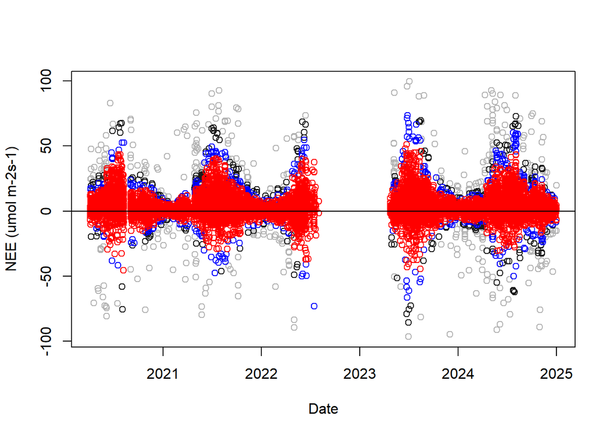

```
## integer(0)
```

```r
NEE_high <- ifelse(flag == 1, NA, eddy_fcr$co2_flux_umolm2s)

# Plot flagged data:
plot(eddy_fcr$datetime,eddy_fcr$co2_flux_umolm2s,xlab = "Date", ylab = "NEE (umol m-2s-1)", col = "gray70")+
points(eddy_fcr$datetime,NEE_low,col = "gray10")+
points(eddy_fcr$datetime,NEE_medium,col = "blue")+
points(eddy_fcr$datetime,NEE_high,col = "red")+
abline(h=0)
```

```r
# Combine all flagged data
eddy_fcr$NEE.low <- NEE_low
eddy_fcr$NEE.med <- NEE_medium
eddy_fcr$NEE.high <- NEE_high

#Despike CH4 flux
flag <- spike_flag(eddy_fcr$ch4_flux_umolm2s,z = 7)
```

```
## No. of outliers in left tail: 1
```

```
## No. of outliers in right tail: 0
```

```
## No. of outliers in left tail: 1
```

```
## No. of outliers in right tail: 4
```

```
## No outliers found
```

```
## No. of outliers in left tail: 0
```

```
## No. of outliers in right tail: 1
```

```
## No outliers found
```

```
## No. of outliers in left tail: 0
```

```
## No. of outliers in right tail: 15
```

```
## No outliers found
```

```
## No. of outliers in left tail: 0
```

```
## No. of outliers in right tail: 1
```

```
## No. of outliers in left tail: 2
```

```
## No. of outliers in right tail: 1
```

```
## No. of outliers in left tail: 3
```

```
## No. of outliers in right tail: 3
```

```
## No outliers found
```

```
## No. of outliers in left tail: 2
```

```
## No. of outliers in right tail: 3
```

```
## No. of outliers in left tail: 0
```

```
## No. of outliers in right tail: 1
```

```
## No. of outliers in left tail: 5
```

```
## No. of outliers in right tail: 2
```

```
## No outliers found
## No outliers found
## No outliers found
## No outliers found
## No outliers found
```

```
## No. of outliers in left tail: 0
```

```
## No. of outliers in right tail: 11
```

```
## No. of outliers in left tail: 0
```

```
## No. of outliers in right tail: 4
```

```
## No. of outliers in left tail: 2
```

```
## No. of outliers in right tail: 4
```

```
## No. of outliers in left tail: 1
```

```
## No. of outliers in right tail: 2
```

```
## No. of outliers in left tail: 2
```

```
## No. of outliers in right tail: 2
```

```
## No. of outliers in left tail: 5
```

```
## No. of outliers in right tail: 2
```

```
## No. of outliers in left tail: 4
```

```
## No. of outliers in right tail: 1
```

```
## No. of outliers in left tail: 1
```

```
## No. of outliers in right tail: 1
```

```
## No outliers found
## No outliers found
## No outliers found
```

```
## No. of outliers in left tail: 0
```

```
## No. of outliers in right tail: 1
```

```
## No outliers found
## No outliers found
## No outliers found
```

```
## No. of outliers in left tail: 0
```

```
## No. of outliers in right tail: 1
```

```
## No outliers found
```

```
## No. of outliers in left tail: 1
```

```
## No. of outliers in right tail: 0
```

```
## No. of outliers in left tail: 0
```

```
## No. of outliers in right tail: 2
```

```
## No. of outliers in left tail: 0
```

```
## No. of outliers in right tail: 1
```

```
## No. of outliers in left tail: 1
```

```
## No. of outliers in right tail: 0
```

```
## No. of outliers in left tail: 0
```

```
## No. of outliers in right tail: 1
```

```
## No. of outliers in left tail: 1
```

```
## No. of outliers in right tail: 1
```

```
## No. of outliers in left tail: 2
```

```
## No. of outliers in right tail: 1
```

```
## No. of outliers in left tail: 0
```

```
## No. of outliers in right tail: 1
```

```
## No. of outliers in left tail: 1
```

```
## No. of outliers in right tail: 0
```

```
## No. of outliers in left tail: 2
```

```
## No. of outliers in right tail: 3
```

```
## No. of outliers in left tail: 2
```

```
## No. of outliers in right tail: 3
```

```
## No. of outliers in left tail: 3
```

```
## No. of outliers in right tail: 7
```

```
## No. of outliers in left tail: 5
```

```
## No. of outliers in right tail: 6
```

```
## No outliers found
```

```
## No. of outliers in left tail: 4
```

```
## No. of outliers in right tail: 4
```

```
## No outliers found
```

```
## No. of outliers in left tail: 0
```

```
## No. of outliers in right tail: 2
```

```
## No. of outliers in left tail: 0
```

```
## No. of outliers in right tail: 1
```

```
## No. of outliers in left tail: 1
```

```
## No. of outliers in right tail: 0
```

```
## No. of outliers in left tail: 1
```

```
## No. of outliers in right tail: 0
```

```
## No. of outliers in left tail: 0
```

```
## No. of outliers in right tail: 2
```

```
## No. of outliers in left tail: 0
```

```
## No. of outliers in right tail: 3
```

```r
CH4_low <- ifelse(flag == 1, NA, eddy_fcr$ch4_flux_umolm2s)
flag <- spike_flag(eddy_fcr$ch4_flux_umolm2s,z = 5.5)
```

```
## No. of outliers in left tail: 5
```

```
## No. of outliers in right tail: 2
```

```
## No. of outliers in left tail: 1
```

```
## No. of outliers in right tail: 4
```

```
## No. of outliers in left tail: 2
```

```
## No. of outliers in right tail: 1
```

```
## No. of outliers in left tail: 0
```

```
## No. of outliers in right tail: 2
```

```
## No outliers found
```

```
## No. of outliers in left tail: 0
```

```
## No. of outliers in right tail: 25
```

```
## No. of outliers in left tail: 0
```

```
## No. of outliers in right tail: 1
```

```
## No. of outliers in left tail: 0
```

```
## No. of outliers in right tail: 1
```

```
## No. of outliers in left tail: 4
```

```
## No. of outliers in right tail: 3
```

```
## No. of outliers in left tail: 5
```

```
## No. of outliers in right tail: 4
```

```
## No outliers found
```

```
## No. of outliers in left tail: 5
```

```
## No. of outliers in right tail: 4
```

```
## No. of outliers in left tail: 0
```

```
## No. of outliers in right tail: 2
```

```
## No. of outliers in left tail: 5
```

```
## No. of outliers in right tail: 3
```

```
## No. of outliers in left tail: 1
```

```
## No. of outliers in right tail: 2
```

```
## No outliers found
```

```
## No. of outliers in left tail: 1
```

```
## No. of outliers in right tail: 1
```

```
## No outliers found
## No outliers found
```

```
## No. of outliers in left tail: 0
```

```
## No. of outliers in right tail: 14
```

```
## No. of outliers in left tail: 3
```

```
## No. of outliers in right tail: 6
```

```
## No. of outliers in left tail: 3
```

```
## No. of outliers in right tail: 6
```

```
## No. of outliers in left tail: 2
```

```
## No. of outliers in right tail: 6
```

```
## No. of outliers in left tail: 3
```

```
## No. of outliers in right tail: 6
```

```
## No. of outliers in left tail: 7
```

```
## No. of outliers in right tail: 2
```

```
## No. of outliers in left tail: 4
```

```
## No. of outliers in right tail: 1
```

```
## No. of outliers in left tail: 2
```

```
## No. of outliers in right tail: 2
```

```
## No outliers found
## No outliers found
## No outliers found
```

```
## No. of outliers in left tail: 0
```

```
## No. of outliers in right tail: 2
```

```
## No outliers found
```

```
## No. of outliers in left tail: 0
```

```
## No. of outliers in right tail: 2
```

```
## No outliers found
```

```
## No. of outliers in left tail: 0
```

```
## No. of outliers in right tail: 1
```

```
## No outliers found
```

```
## No. of outliers in left tail: 1
```

```
## No. of outliers in right tail: 2
```

```
## No. of outliers in left tail: 0
```

```
## No. of outliers in right tail: 4
```

```
## No. of outliers in left tail: 0
```

```
## No. of outliers in right tail: 1
```

```
## No. of outliers in left tail: 1
```

```
## No. of outliers in right tail: 0
```

```
## No. of outliers in left tail: 0
```

```
## No. of outliers in right tail: 2
```

```
## No. of outliers in left tail: 1
```

```
## No. of outliers in right tail: 2
```

```
## No. of outliers in left tail: 3
```

```
## No. of outliers in right tail: 3
```

```
## No. of outliers in left tail: 0
```

```
## No. of outliers in right tail: 3
```

```
## No. of outliers in left tail: 2
```

```
## No. of outliers in right tail: 0
```

```
## No. of outliers in left tail: 4
```

```
## No. of outliers in right tail: 5
```

```
## No. of outliers in left tail: 3
```

```
## No. of outliers in right tail: 5
```

```
## No. of outliers in left tail: 4
```

```
## No. of outliers in right tail: 10
```

```
## No. of outliers in left tail: 8
```

```
## No. of outliers in right tail: 6
```

```
## No. of outliers in left tail: 1
```

```
## No. of outliers in right tail: 1
```

```
## No. of outliers in left tail: 4
```

```
## No. of outliers in right tail: 5
```

```
## No. of outliers in left tail: 2
```

```
## No. of outliers in right tail: 1
```

```
## No. of outliers in left tail: 1
```

```
## No. of outliers in right tail: 2
```

```
## No. of outliers in left tail: 2
```

```
## No. of outliers in right tail: 1
```

```
## No. of outliers in left tail: 2
```

```
## No. of outliers in right tail: 0
```

```
## No. of outliers in left tail: 1
```

```
## No. of outliers in right tail: 0
```

```
## No. of outliers in left tail: 1
```

```
## No. of outliers in right tail: 3
```

```
## No. of outliers in left tail: 1
```

```
## No. of outliers in right tail: 5
```

```r
CH4_medium <- ifelse(flag == 1, NA, eddy_fcr$ch4_flux_umolm2s)
flag <- spike_flag(eddy_fcr$ch4_flux_umolm2s,z = 4)
```

```
## No. of outliers in left tail: 7
```

```
## No. of outliers in right tail: 3
```

```
## No. of outliers in left tail: 4
```

```
## No. of outliers in right tail: 6
```

```
## No. of outliers in left tail: 3
```

```
## No. of outliers in right tail: 3
```

```
## No. of outliers in left tail: 1
```

```
## No. of outliers in right tail: 2
```

```
## No outliers found
```

```
## No. of outliers in left tail: 0
```

```
## No. of outliers in right tail: 34
```

```
## No. of outliers in left tail: 1
```

```
## No. of outliers in right tail: 1
```

```
## No. of outliers in left tail: 3
```

```
## No. of outliers in right tail: 5
```

```
## No. of outliers in left tail: 5
```

```
## No. of outliers in right tail: 3
```

```
## No. of outliers in left tail: 11
```

```
## No. of outliers in right tail: 8
```

```
## No. of outliers in left tail: 0
```

```
## No. of outliers in right tail: 1
```

```
## No. of outliers in left tail: 7
```

```
## No. of outliers in right tail: 9
```

```
## No. of outliers in left tail: 1
```

```
## No. of outliers in right tail: 3
```

```
## No. of outliers in left tail: 9
```

```
## No. of outliers in right tail: 9
```

```
## No. of outliers in left tail: 2
```

```
## No. of outliers in right tail: 6
```

```
## No. of outliers in left tail: 1
```

```
## No. of outliers in right tail: 2
```

```
## No. of outliers in left tail: 1
```

```
## No. of outliers in right tail: 2
```

```
## No. of outliers in left tail: 1
```

```
## No. of outliers in right tail: 2
```

```
## No. of outliers in left tail: 1
```

```
## No. of outliers in right tail: 1
```

```
## No. of outliers in left tail: 0
```

```
## No. of outliers in right tail: 25
```

```
## No. of outliers in left tail: 4
```

```
## No. of outliers in right tail: 13
```

```
## No. of outliers in left tail: 5
```

```
## No. of outliers in right tail: 7
```

```
## No. of outliers in left tail: 3
```

```
## No. of outliers in right tail: 8
```

```
## No. of outliers in left tail: 4
```

```
## No. of outliers in right tail: 11
```

```
## No. of outliers in left tail: 9
```

```
## No. of outliers in right tail: 4
```

```
## No. of outliers in left tail: 6
```

```
## No. of outliers in right tail: 4
```

```
## No. of outliers in left tail: 6
```

```
## No. of outliers in right tail: 2
```

```
## No outliers found
## No outliers found
## No outliers found
```

```
## No. of outliers in left tail: 0
```

```
## No. of outliers in right tail: 3
```

```
## No outliers found
```

```
## No. of outliers in left tail: 1
```

```
## No. of outliers in right tail: 3
```

```
## No. of outliers in left tail: 0
```

```
## No. of outliers in right tail: 1
```

```
## No. of outliers in left tail: 1
```

```
## No. of outliers in right tail: 5
```

```
## No. of outliers in left tail: 0
```

```
## No. of outliers in right tail: 1
```

```
## No. of outliers in left tail: 1
```

```
## No. of outliers in right tail: 2
```

```
## No. of outliers in left tail: 1
```

```
## No. of outliers in right tail: 4
```

```
## No. of outliers in left tail: 0
```

```
## No. of outliers in right tail: 1
```

```
## No. of outliers in left tail: 4
```

```
## No. of outliers in right tail: 2
```

```
## No. of outliers in left tail: 4
```

```
## No. of outliers in right tail: 4
```

```
## No. of outliers in left tail: 1
```

```
## No. of outliers in right tail: 4
```

```
## No. of outliers in left tail: 6
```

```
## No. of outliers in right tail: 3
```

```
## No. of outliers in left tail: 3
```

```
## No. of outliers in right tail: 9
```

```
## No. of outliers in left tail: 2
```

```
## No. of outliers in right tail: 2
```

```
## No. of outliers in left tail: 10
```

```
## No. of outliers in right tail: 11
```

```
## No. of outliers in left tail: 4
```

```
## No. of outliers in right tail: 6
```

```
## No. of outliers in left tail: 7
```

```
## No. of outliers in right tail: 14
```

```
## No. of outliers in left tail: 10
```

```
## No. of outliers in right tail: 9
```

```
## No. of outliers in left tail: 1
```

```
## No. of outliers in right tail: 2
```

```
## No. of outliers in left tail: 7
```

```
## No. of outliers in right tail: 9
```

```
## No. of outliers in left tail: 4
```

```
## No. of outliers in right tail: 3
```

```
## No. of outliers in left tail: 1
```

```
## No. of outliers in right tail: 3
```

```
## No. of outliers in left tail: 2
```

```
## No. of outliers in right tail: 4
```

```
## No. of outliers in left tail: 3
```

```
## No. of outliers in right tail: 1
```

```
## No. of outliers in left tail: 3
```

```
## No. of outliers in right tail: 4
```

```
## No. of outliers in left tail: 6
```

```
## No. of outliers in right tail: 9
```

```
## No. of outliers in left tail: 4
```

```
## No. of outliers in right tail: 9
```

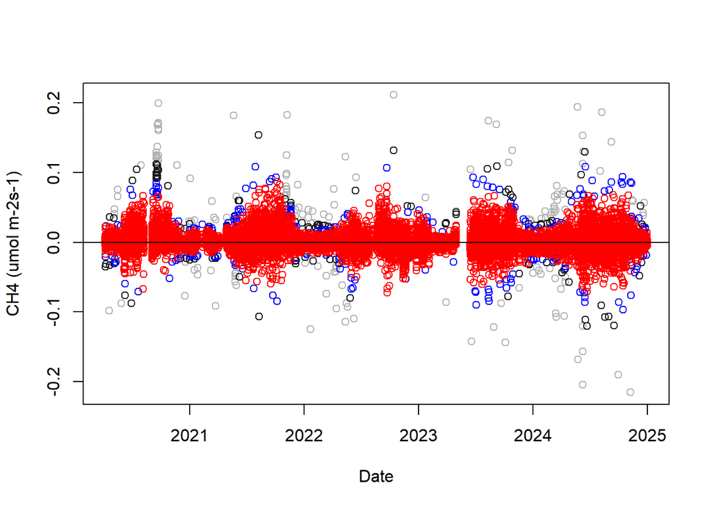

```
## integer(0)
```

```r
CH4_high <- ifelse(flag == 1, NA, eddy_fcr$ch4_flux_umolm2s)

# Plot flagged data:
plot(eddy_fcr$datetime,eddy_fcr$ch4_flux_umolm2s,xlab = "Date", ylab = "CH4 (umol m-2s-1)", col = "gray70")+
points(eddy_fcr$datetime,CH4_low,col = "gray10")+
points(eddy_fcr$datetime,CH4_medium,col = "blue")+
points(eddy_fcr$datetime,CH4_high,col = "red")+
abline(h=0)
```

```r
# Combine all flagged data
eddy_fcr$ch4.low <- CH4_low
eddy_fcr$ch4.med <- CH4_medium
eddy_fcr$ch4.high <- CH4_high
```

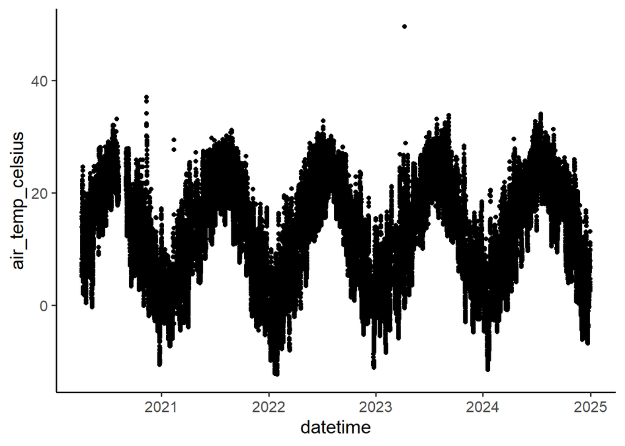

```r
##########################################################################
# Convert EC temperature to celsius
eddy_fcr$air_temp_celsius <- eddy_fcr$air_temperature_k - 273.15
eddy_fcr$sonic_temp_celsius <- eddy_fcr$sonic_temperature_k - 273.15

# Plot temperature
ggplot(eddy_fcr,mapping=aes(x=datetime,y=air_temp_celsius))+
  geom_point()+
  theme_classic(base_size=15)
```

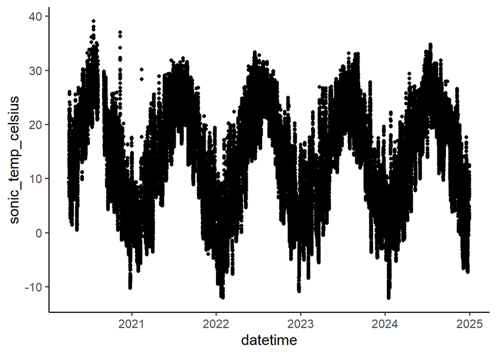

```r
ggplot(eddy_fcr,mapping=aes(x=datetime,y=sonic_temp_celsius))+
  geom_point()+
  theme_classic(base_size=15)
```

```r
# Remove any values over 40

eddy_fcr$air_temp_celsius <- ifelse(eddy_fcr$air_temp_celsius>40, NA,
                                    eddy_fcr$air_temp_celsius)

# Remove bad air temps on 10 Feb to 14 Feb
eddy_fcr$air_temp_celsius <- ifelse(eddy_fcr$datetime >= '2021-02-10' & eddy_fcr$datetime <='2021-02-14', NA,
                                    eddy_fcr$air_temp_celsius)
eddy_fcr$sonic_temp_celsius <- ifelse(eddy_fcr$datetime >= '2021-02-10' & eddy_fcr$datetime <='2021-02-14', NA,
                                      eddy_fcr$sonic_temp_celsius)

# Remove high temperatures on 11 November 2020
eddy_fcr$air_temp_celsius <- ifelse(eddy_fcr$datetime >= '2020-11-11' & eddy_fcr$datetime <'2020-11-12', NA,
                                    eddy_fcr$air_temp_celsius)

eddy_fcr$sonic_temp_celsius <- ifelse(eddy_fcr$datetime >= '2020-11-11' & eddy_fcr$datetime <'2020-11-12', NA,
                                    eddy_fcr$sonic_temp_celsius)
```

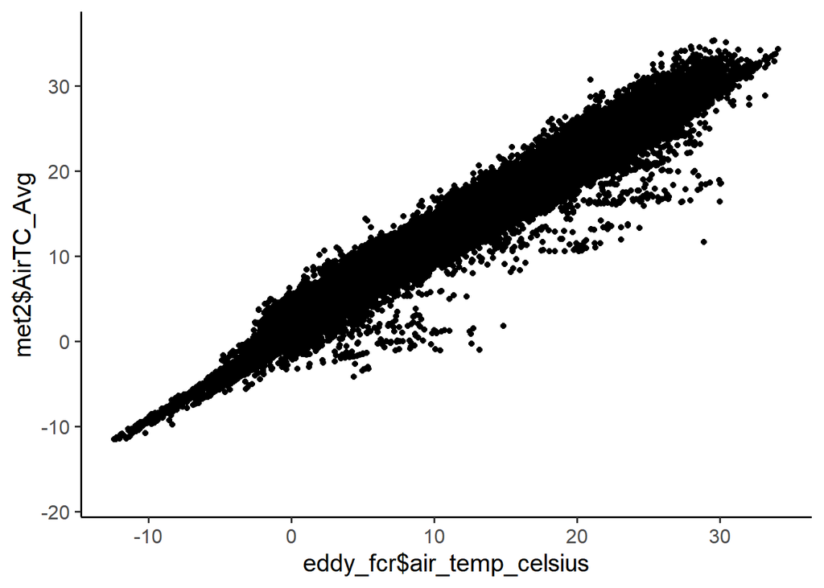

```r
# Replacing Eddy Flux air temp with Met air temp
# Check correlations between EC temp and Met Temp
ggplot()+
  geom_point(aes(x=eddy_fcr$air_temp_celsius,y=met2$AirTC_Avg))+
  theme_classic(base_size = 15)
```

```r
# Calculate percent of missing air temp data
# 37.57% missing
eddy_fcr %>% select(datetime, air_temp_celsius) %>%
  summarise(temp_na = sum(is.na(air_temp_celsius))/n()*100)
```

```
##    temp_na
## 1 37.57296
```

```r
# Use linear model to estimate EC temp from Met temp
linearMod_Air <- lm(eddy_fcr$air_temp_celsius ~ met2$AirTC_Avg)
summary(linearMod_Air)
```

```
##
## Call:
## lm(formula = eddy_fcr$air_temp_celsius ~ met2$AirTC_Avg)
##
## Residuals:
##     Min      1Q  Median      3Q     Max
## -8.0994 -0.8168 -0.0263  0.8475 18.4380
##
## Coefficients:
##                  Estimate Std. Error t value Pr(>|t|)
## (Intercept)    -0.9595196  0.0131927  -72.73   <2e-16 ***
## met2$AirTC_Avg  0.9753170  0.0007933 1229.46   <2e-16 ***
## ---
## Signif. codes:  0 '***' 0.001 '**' 0.01 '*' 0.05 '.' 0.1 ' ' 1
##
## Residual standard error: 1.6 on 51858 degrees of freedom
##   (31229 observations deleted due to missingness)
## Multiple R-squared:  0.9668, Adjusted R-squared:  0.9668
## F-statistic: 1.512e+06 on 1 and 51858 DF,  p-value: < 2.2e-16
```

```r
cor(eddy_fcr[[88]],met2[[4]],use = "complete.obs",method=c("pearson"))
```

```
## [1] 0.9832755
```

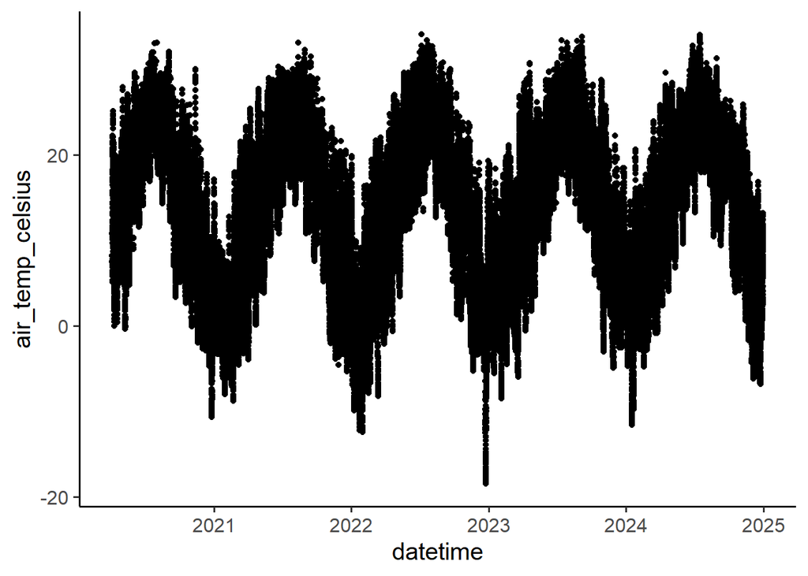

```r
# EC = Met*0.9753170-0.9595196
# UPDATE RELATIONSHIP EACH YEAR!!

eddy_fcr$air_temp_celsius <- ifelse(is.na(eddy_fcr$air_temp_celsius),
                                    met2$AirTC_Avg*(summary(linearMod_Air)$coefficients[2, 1])+
                           (summary(linearMod_Air)$coefficients[1, 1]), eddy_fcr$air_temp_celsius)

# Check Air Temp
ggplot(eddy_fcr,mapping=aes(x=datetime,y=air_temp_celsius))+
  geom_point()+
  theme_classic(base_size=15)
```

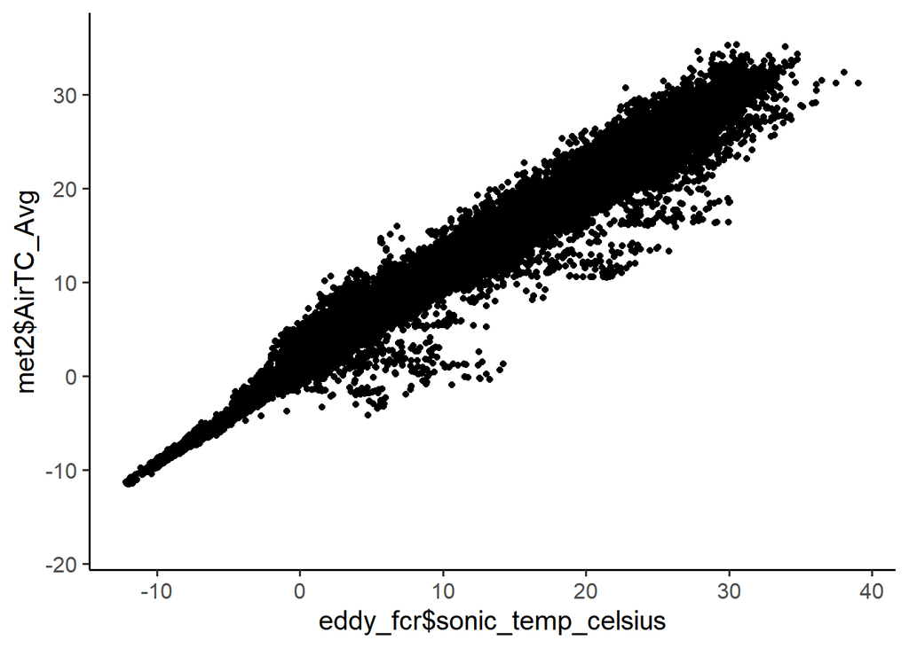

```r
# Check correlations between EC temp (sonic) and Met Temp
ggplot()+
  geom_point(aes(x=eddy_fcr$sonic_temp_celsius,y=met2$AirTC_Avg))+
  theme_classic(base_size = 15)
```

```r
# Calculate percent of missing sonic temp data
# 37.57% missing
eddy_fcr %>% select(datetime, sonic_temp_celsius) %>%
  summarise(temp_na = sum(is.na(sonic_temp_celsius))/n()*100)
```

```
##    temp_na
## 1 37.57176
```

```r
# Use linear model to estimate EC temp and Met temp
linearMod_Air2 <- lm(eddy_fcr$sonic_temp_celsius ~ met2$AirTC_Avg)
summary(linearMod_Air2)
```

```
##
## Call:
## lm(formula = eddy_fcr$sonic_temp_celsius ~ met2$AirTC_Avg)
##
## Residuals:
##     Min      1Q  Median      3Q     Max
## -9.0489 -0.7234  0.1271  0.7681 14.4091
##
## Coefficients:
##                  Estimate Std. Error t value Pr(>|t|)
## (Intercept)    -0.7605165  0.0133162  -57.11   <2e-16 ***
## met2$AirTC_Avg  1.0395534  0.0008007 1298.27   <2e-16 ***
## ---
## Signif. codes:  0 '***' 0.001 '**' 0.01 '*' 0.05 '.' 0.1 ' ' 1
##
## Residual standard error: 1.615 on 51859 degrees of freedom
##   (31228 observations deleted due to missingness)
## Multiple R-squared:  0.9702, Adjusted R-squared:  0.9702
## F-statistic: 1.686e+06 on 1 and 51859 DF,  p-value: < 2.2e-16
```

```r
cor(eddy_fcr[[89]],met2[[4]],use = "complete.obs",method=c("pearson"))
```

```
## [1] 0.9849624
```

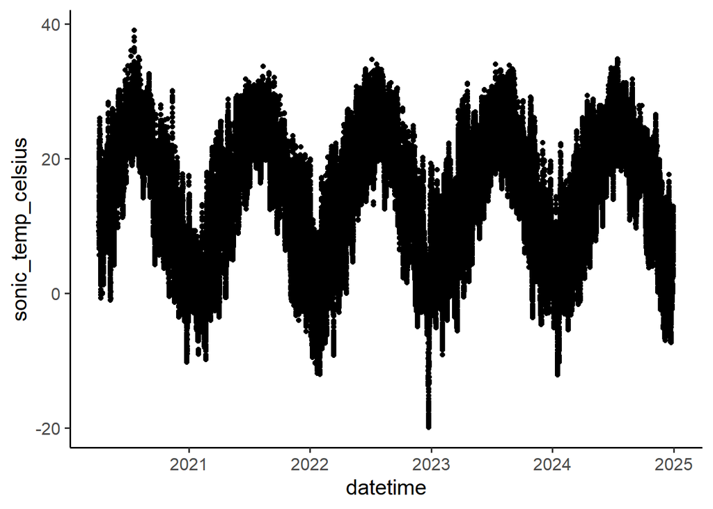

```r
# EC = Met*1.0395534-0.7605165
# UPDATE RELATIONSHIP EACH YEAR!!

eddy_fcr$sonic_temp_celsius <- ifelse(is.na(eddy_fcr$sonic_temp_celsius),
                                      eddy_fcr$air_temp_celsius*(summary(linearMod_Air2)$coefficients[2, 1])+
                           (summary(linearMod_Air2)$coefficients[1, 1]), eddy_fcr$sonic_temp_celsius)

# Check sonic temp
ggplot(eddy_fcr,mapping=aes(x=datetime,y=sonic_temp_celsius))+
  geom_point()+
  theme_classic(base_size=15)
```

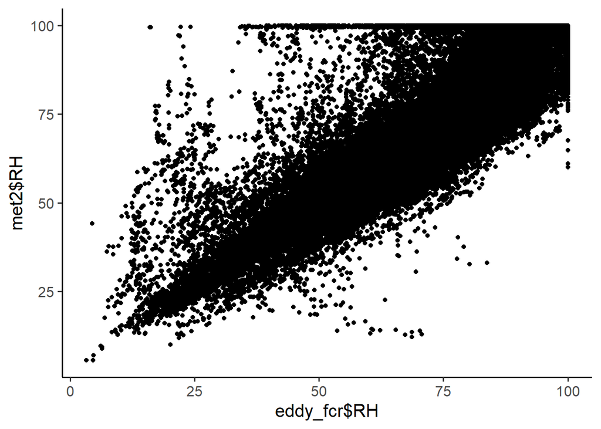

```r
# Replacing Eddy Flux RH with Met RH
# Check correlations between EC and Met RH
ggplot()+
  geom_point(aes(x=eddy_fcr$RH,y=met2$RH))+
  theme_classic(base_size = 15)
```

```r
# Calculate percent of missing RH
# 47.27% missing
eddy_fcr %>% select(datetime, RH) %>%
  summarise(RH_na = sum(is.na(RH))/n()*100)
```

```
##      RH_na
## 1 47.27581
```

```r
# Use linear model to estimate EC RH from Met RH
linearMod_RH <- lm(eddy_fcr$RH ~ met2$RH)
summary(linearMod_RH)
```

```
##
## Call:
## lm(formula = eddy_fcr$RH ~ met2$RH)
##
## Residuals:
##     Min      1Q  Median      3Q     Max
## -77.276  -4.480   0.862   5.912  49.944
##
## Coefficients:
##             Estimate Std. Error t value Pr(>|t|)
## (Intercept) 9.891706   0.168074   58.85   <2e-16 ***
## met2$RH     0.838366   0.002198  381.42   <2e-16 ***
## ---
## Signif. codes:  0 '***' 0.001 '**' 0.01 '*' 0.05 '.' 0.1 ' ' 1
##
## Residual standard error: 10.01 on 43761 degrees of freedom
##   (39326 observations deleted due to missingness)
## Multiple R-squared:  0.7688, Adjusted R-squared:  0.7688
## F-statistic: 1.455e+05 on 1 and 43761 DF,  p-value: < 2.2e-16
```

```r
cor(eddy_fcr[[46]],met2[[5]],use = "complete.obs",method=c("pearson"))
```

```
## [1] 0.8767896
```

```r
# EC = Met*0.838366 + 9.891706
# UPDATE EACH YEAR!!

eddy_fcr$RH <- ifelse(is.na(eddy_fcr$RH),
                      met2$RH*(summary(linearMod_RH)$coefficients[2, 1])+
                           (summary(linearMod_RH)$coefficients[1, 1]), eddy_fcr$RH)

# Add Met data to gapfill fluxes
eddy_fcr$SW_in <- met2$SW_in
eddy_fcr$SW_out <- met2$SW_out
eddy_fcr$par_tot <- met2$PAR_Tot_Tot
eddy_fcr$air_pressure <- met2$Pressure
eddy_fcr$LW_in <- met2$LW_in
eddy_fcr$LW_out <- met2$LW_out
eddy_fcr$albedo <- met2$albedo
```

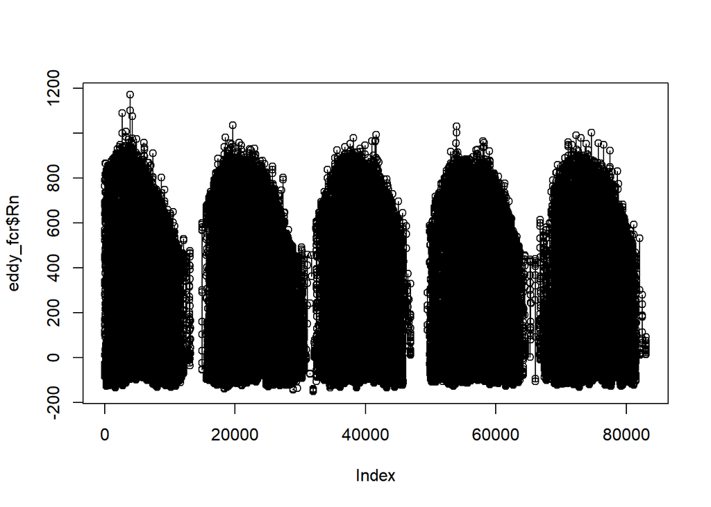

```r
# Calculate vapor pressure deficit from RH and Air Temp using Met data
eddy_fcr$VPD <- ifelse(is.na(eddy_fcr$VPD),
                       fCalcVPDfromRHandTair(rH = eddy_fcr$RH, Tair = eddy_fcr$air_temp_celsius)*100,
                       eddy_fcr$VPD)

# Remove funky PAR_Tot values
eddy_fcr$par_tot <- ifelse(eddy_fcr$datetime >='2020-07-03' & eddy_fcr$datetime <= '2020-07-22', NA, eddy_fcr$par_tot)

# Replace wind_direction in EC data with Met data if missing
eddy_fcr$wind_dir <- ifelse(is.na(eddy_fcr$wind_dir), met4$WindDir, eddy_fcr$wind_dir)

# QA/QC'ing LW_out data
eddy_fcr$LW_out <- ifelse(eddy_fcr$LW_out <= 360, NA, eddy_fcr$LW_out)
eddy_fcr$LW_out <- ifelse(eddy_fcr$datetime >= '2020-06-22' & eddy_fcr$datetime <= '2020-07-13' & eddy_fcr$LW_out <= 420, NA, eddy_fcr$LW_out)

# Calculating Net Radiation
eddy_fcr$Rn <- eddy_fcr$SW_in - eddy_fcr$SW_out + eddy_fcr$LW_in - eddy_fcr$LW_out

plot(eddy_fcr$Rn, type = 'o')
```

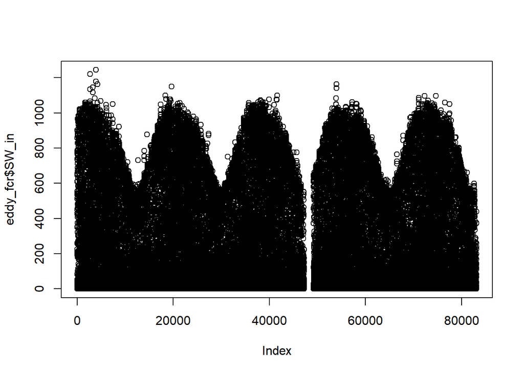

```r
plot(eddy_fcr$SW_in)
```

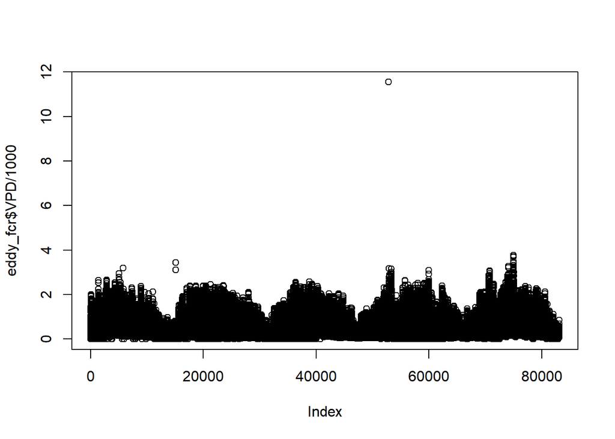

```r
plot(eddy_fcr$VPD/1000)  # in kpa
```

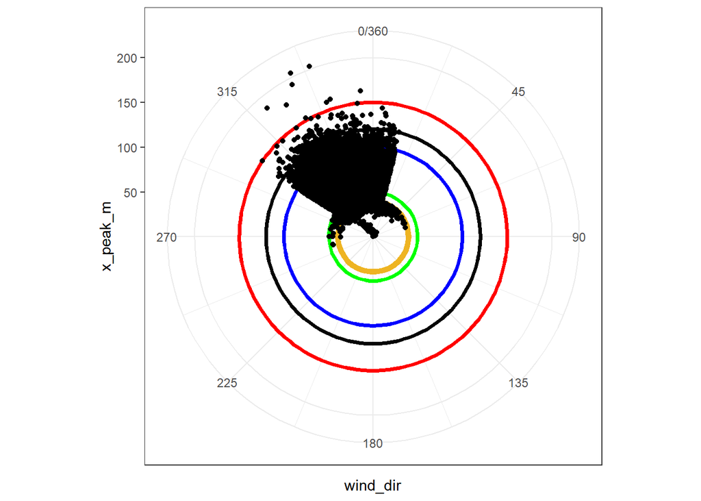

```r
###############################################################################
# Filter out all the values (x_peak) that are out of the reservoir
eddy_fcr$footprint_flag <- ifelse(eddy_fcr$wind_dir >= 15 & eddy_fcr$wind_dir <= 90 & eddy_fcr$x_peak_m >= 40, 1,
                                  ifelse(eddy_fcr$wind_dir < 15 & eddy_fcr$wind_dir > 327 & eddy_fcr$x_peak_m > 120, 1,
                                         ifelse(eddy_fcr$wind_dir < 302 & eddy_fcr$wind_dir >= 250 & eddy_fcr$x_peak_m > 50, 1, 0)))

# Remove flagged data
eddy_fcr_footprint <- eddy_fcr %>% filter(footprint_flag == 0)

# Visualize wind directions that were kept
eddy_fcr_footprint %>% ggplot(aes(wind_dir, x_peak_m)) +
  geom_hline(yintercept = 40, col = 'goldenrod2', lwd = 2) +
  geom_hline(yintercept = 50, col = 'green', lwd = 1.4) +
  geom_hline(yintercept = 100, col = 'blue', lwd = 1.4) +
  geom_hline(yintercept = 120, col = 'gray2', lwd = 1.4) +
  geom_hline(yintercept = 150, col = 'red',lwd = 1.4) +
  geom_point() +
  scale_x_continuous(limits = c(0, 360),
                     breaks = seq(0, 360, 45)) +
  theme_bw() +
  coord_polar()
```

```r
# merge with timeseries
eddy_fcr_footprint_full <- left_join(ts2, eddy_fcr_footprint)
write.csv(eddy_fcr_footprint_full, "Eddy_fcr_footprint_full.csv")
```

```r
######################################################################
# FILTERING BY USTAR AND GAPFILLING
######################################################################

# Setting up a new process on REddyProc
eddy_fcr3 <- eddy_fcr_footprint_full %>%
  select(DateTime = datetime, NEE = NEE.med, ch4_flux = ch4.med, VPD,
         H = H_wm2, LE = LE_wm2, Tair = sonic_temp_celsius, rH = RH, Ustar = u_star_ms, u = wind_speed_ms,
         pressure = air_pressure, L = L_m, z_d_L = MO_stability, sigma_v = v_var_ms,
         precip, Rn, SW_in, SW_out, LW_out, LW_in, albedo, par_tot, wind_dir,
         airP = air_pressure) %>%
  mutate(VPD = VPD/100,
         z_d = z_d_L*L,
         ln_z_d = log(z_d),
         daytime = ifelse(SW_in >= 12, 1, 0)) %>%
  rename(Rg = SW_in,
         PAR = par_tot)

########################################################################
# Count available data before gapfilling
eddy_fcr3 %>% select(DateTime, NEE, ch4_flux) %>%
  summarise(co2_available = 100-sum(is.na(NEE))/n()*100,
            ch4_available = 100-sum(is.na(ch4_flux))/n()*100)
```

```
##   co2_available ch4_available
## 1       24.0104      22.87306
```

```r
# 24% CO2 data; 22.87% CH4 data

# Total number of available time points
eddy_fcr3 %>% select(DateTime, NEE, ch4_flux) %>%
  summarise(co2_available = n()-sum(is.na(NEE)),
            ch4_available = n()-sum(is.na(ch4_flux)))
```

```
##   co2_available ch4_available
## 1         19950         19005
```

```r
# Counting data availability by month
eddy_fcr3 %>% group_by(year(DateTime), month(DateTime)) %>%
  select(DateTime, NEE, ch4_flux) %>%
  summarise(co2_available = 100-sum(is.na(NEE))/n()*100,
            ch4_available = 100-sum(is.na(ch4_flux))/n()*100)
```

```
## # A tibble: 57 × 4
## # Groups:   year(DateTime) [5]
##    `year(DateTime)` `month(DateTime)` co2_available ch4_available
##               <dbl>             <dbl>         <dbl>         <dbl>
##  1             2020                 4         26.0          17.8
##  2             2020                 5         25.1          20.2
##  3             2020                 6         26.0          20
##  4             2020                 7         29.0          22.3
##  5             2020                 8          5.51          3.70
##  6             2020                 9         29.2          25.9
##  7             2020                10         31.7          21.8
##  8             2020                11         31.5          30.5
##  9             2020                12         32.7          17.3
## 10             2021                 1         34.7          27.5
## # ℹ 47 more rows
```

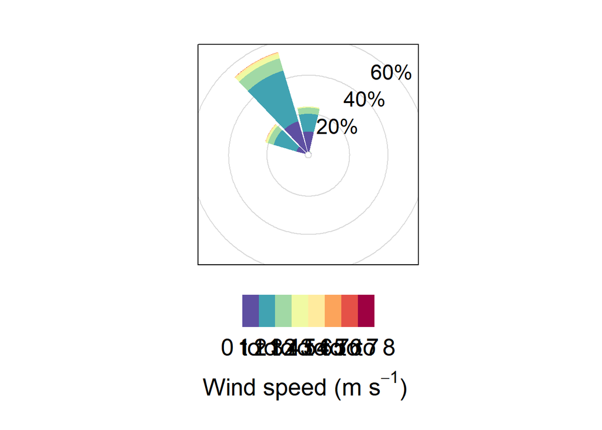

```r
# Visualizing data by wind direction/wind speed
# Save as: 800 x 800
windRose(mydata = eddy_fcr3, ws = "u", wd = "wind_dir",
         width = 3, key.position = 'bottom',
         offset = 3, paddle = FALSE, key.header = 'Wind speed (m/s)',
         key.footer = ' ', dig.lab = 2, annotate = FALSE,
         angle.scale = 45, ws.int = 1, breaks = c(0, 1, 2, 3, 4, 5, 6, 7, 8),
         par.settings = list(fontsize=list(text=25)))
```

###Let’s look at data availability for NEE

```r
###########################################################################
# get ustar distribution and filter by ustar
###########################################################################
# Gapfilling - using periods of similar met.
# Following Eddy Proc
Eproc <- sEddyProc$new('FCR', eddy_fcr3, c('NEE','Tair', 'VPD',
                                           'rH','H', 'LE', 'Ustar',
                                           'ch4_flux', 'u', 'PAR',
                                           'SW_out', 'Rg',
                                           'Rn', 'LW_out', 'LW_in'))
```

```
## New sEddyProc class for site 'FCR'
```

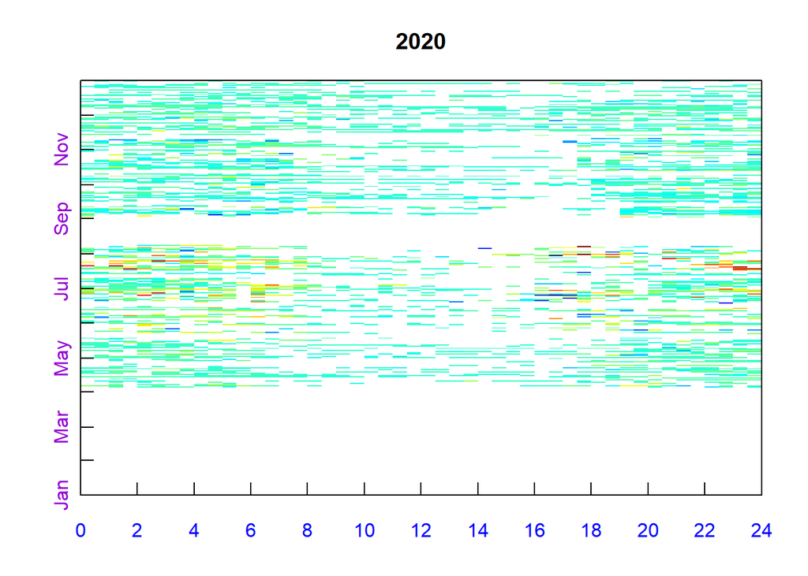

```r
# Look at available data for each year/flux
Eproc$sPlotFingerprintY('NEE',Year = '2020')
```

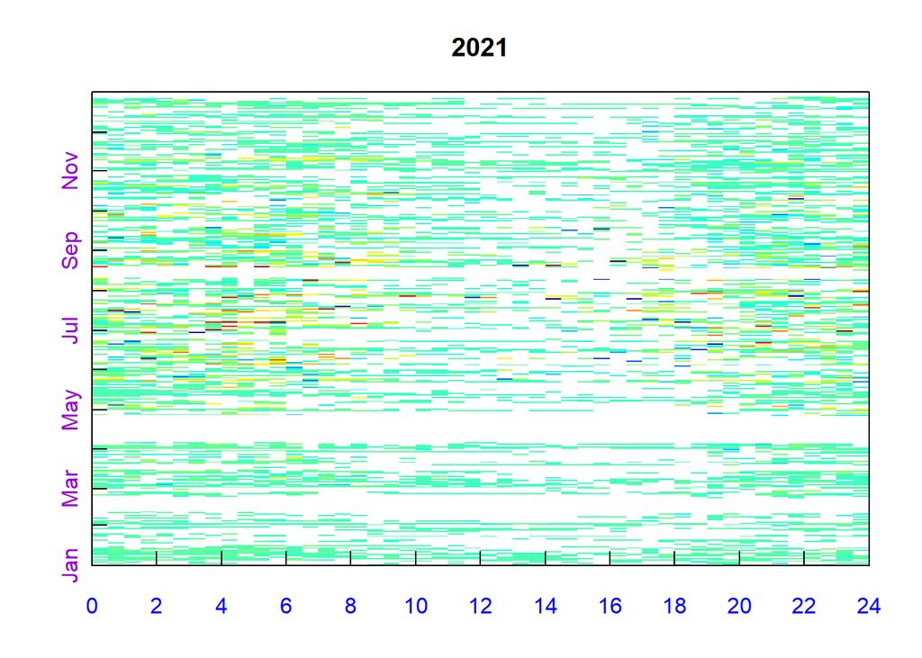

```r
Eproc$sPlotFingerprintY('NEE',Year = '2021')
```

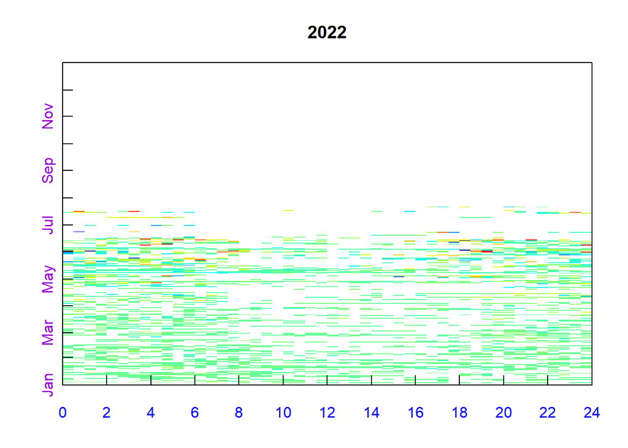

```r
Eproc$sPlotFingerprintY('NEE',Year = '2022')
```

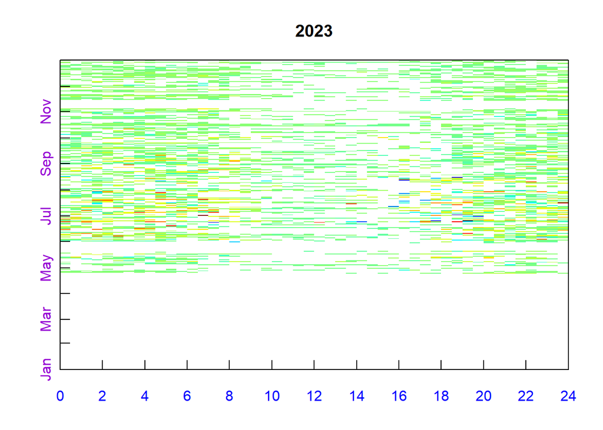

```r
Eproc$sPlotFingerprintY('NEE',Year = '2023')
```